# Week 09 Part 2 R 實作：三種 t 檢定

作者

发布于

2026年11月5日

## 問題與資料

三個案例與 Week 09 t 檢定投影片相同：

- 問題 A（單一樣本）：接受訓練大鼠 RNA 的 25 隻大鼠，平均選擇安全路徑的次數與基準 60 次不同嗎？雙尾，$\alpha=.05$。
- 問題 B（獨立樣本）：自己搜尋答案的人，自評信心是否與只閱讀資訊的人不同？差的方向為搜尋組 − 非搜尋組，雙尾，$\alpha=.001$，採合併法。
- 問題 C（配對）：同一批 20 位大學生觀看影片前後，平均態度分數有改變嗎？差值方向為前測 − 後測，雙尾，$\alpha=.05$。

A、B 只有摘要統計量；C 有完整資料 `week09_part2_film_attitude.csv`。執行程式前，先寫下每個問題該用哪一種 t 檢定，以及自由度是多少。

```r
# 載入套件：dplyr 整理資料、ggplot2 畫圖、readr 讀 CSV
# 本檔的 |> 是 R 內建的管線（R 4.1 以上），把左邊的結果交給右邊函數的第一個引數
library(dplyr)
library(ggplot2)
library(readr)

# 示範資料：只對齊樣本數、平均與標準差，不是原研究的逐筆資料
make_demo <- function(n, mean, sd) {
  z <- rnorm(n)                  # 先抽 n 個標準常態隨機數
  z <- (z - mean(z)) / sd(z)     # 標準化：讓這 n 個數的平均剛好 0、標準差剛好 1
  mean + sd * z                  # 平移、縮放到指定的平均與標準差
}
```

## 0. pt() 與 qt()

```r
# qt()：給機率，回傳 t 值（臨界值）
# 自由度 24、雙尾 α = .05 時，右尾面積 .025，所以累積機率是 .975
qt(0.975, df = 24)
```

```
[1] 2.063899
```

```r
# pt()：給 t 值，回傳左側累積機率
# -abs() 先取到左尾，pt() 得到單尾面積，再乘 2 得到雙尾 p 值
2 * pt(-abs(2.57), df = 24)
```

```
[1] 0.01680383
```

請用一句話說明：為什麼雙尾 $p$ 值要寫成 `2 * pt(-abs(t), df)`，而不是 `pt(t, df)`？

## A. 單一樣本 t 檢定：大鼠迷宮

```r
# 只有摘要統計量時，照公式一步一步算
n <- 25; xbar <- 66; mu0 <- 60; SS <- 3259   # 樣本數、樣本平均、基準值、離均差平方和
s2 <- SS / (n - 1)                  # 樣本變異數
se <- sqrt(s2 / n)                  # 平均數的標準誤
t_rat <- (xbar - mu0) / se          # t 統計量
p_rat <- 2 * pt(-abs(t_rat), df = n - 1)   # 雙尾 p 值，df = n - 1
c(t = t_rat, p = p_rat)
```

```
         t          p
2.57445139 0.01663628
```

```r
qt(1 - 0.05 / 2, df = n - 1)        # 雙尾 α = .05 的臨界值
```

```
[1] 2.063899
```

```r
# 產生 25 筆示範資料；固定 seed，每次執行結果相同
set.seed(1105)
rat <- make_demo(25, mean = 66, sd = sqrt(3259 / 24))

# 放進資料框，用管線檢查平均與 SS 是否和摘要統計量一致
rat_df <- data.frame(choice = rat)
rat_df |>
  summarise(
    mean_choice = mean(choice),                   # 樣本平均，應為 66
    SS          = sum((choice - mean_choice)^2)   # 可直接使用上一行剛算出的 mean_choice；應為 3259
  )
```

```
  mean_choice   SS
1          66 3259
```

```r
# 單一樣本 t 檢定：與基準 μ0 = 60 比較（預設雙尾）
fit_rat <- t.test(rat, mu = 60)
fit_rat
```

```
    One Sample t-test

data:  rat
t = 2.5745, df = 24, p-value = 0.01664
alternative hypothesis: true mean is not equal to 60
95 percent confidence interval:
 61.18989 70.81011
sample estimates:
mean of x
       66
```

```r
# 練習 1：把 alternative 改成 "greater"，取出 p 值
# 先在下方文字預測 p 值會變大、變小或不變，再執行
```

說明單尾與雙尾 $p$ 值的關係，以及本例為何仍以雙尾作結論。

## B. 獨立樣本 t 檢定：網路搜尋

```r
# 兩組的樣本數、平均、變異數（摘要統計量）
n1 <- 93;  m1 <- 3.78; v1 <- 1.42   # 網路搜尋組
n2 <- 102; m2 <- 3.07; v2 <- 1.25   # 非搜尋組

df_pool <- (n1 - 1) + (n2 - 1)                        # 合併法自由度 = n1 + n2 - 2
sp2 <- ((n1 - 1) * v1 + (n2 - 1) * v2) / df_pool      # 合併變異數：以各組自由度加權
se_pool <- sqrt(sp2 * (1 / n1 + 1 / n2))              # 平均差的標準誤
t_pool <- (m1 - m2) / se_pool                         # t 統計量（搜尋組 − 非搜尋組）
c(sp2 = sp2, se = se_pool, t = t_pool, df = df_pool)
```

```
        sp2          se           t          df
  1.3310363   0.1654134   4.2922762 193.0000000
```

```r
qt(1 - 0.001 / 2, df = df_pool)                       # 雙尾 α = .001 的臨界值
```

```
[1] 3.341649
```

```r
2 * pt(-abs(t_pool), df = df_pool)                    # 雙尾 p 值
```

```
[1] 2.796538e-05
```

```r
# 產生長格式示範資料：一列一人，group 標組別、confidence 為自評信心
set.seed(2015)
search <- data.frame(
  group = rep(c("search", "nonsearch"), times = c(n1, n2)),
  confidence = c(make_demo(n1, m1, sqrt(v1)),
                 make_demo(n2, m2, sqrt(v2)))
) |>
  # 設定因子層級的順序；t.test(y ~ group) 會以「第一個層級 − 第二個層級」計算
  mutate(group = factor(group, levels = c("search", "nonsearch")))

# 依組別分組，計算各組的人數、平均與變異數
search |>
  group_by(group) |>
  summarise(
    n    = n(),
    mean = mean(confidence),
    var  = var(confidence)
  )
```

```
# A tibble: 2 × 4
  group         n  mean   var
  <fct>     <int> <dbl> <dbl>
1 search       93  3.78  1.42
2 nonsearch   102  3.07  1.25
```

```r
# 練習：
# 1. 用 t.test() 做合併法（var.equal = TRUE），conf.level 與 alpha = .001 對應
# 2. 拿掉 var.equal，再跑一次，比較 t、df、p
# 3. 計算 Cohen's d（分母為合併標準差 sqrt(sp2)）
```

合併法與 Welch 的結果差在哪裡？`levels` 若改成 `c("nonsearch", "search")`，輸出哪些地方會變？

## C. 配對 t 檢定：影片前後測

```r
# 讀入寬格式資料：一列一人，pre、post 為同一人的前測與後測
film <- read_csv("week09_part2_film_attitude.csv") |>
  mutate(D = pre - post)     # 新增差值欄 D，方向為前測 − 後測
glimpse(film)                # 檢查欄位名稱、型態與前幾筆
```

```
Rows: 20
Columns: 4
$ id   <dbl> 1, 2, 3, 4, 5, 6, 7, 8, 9, 10, 11, 12, 13, 14, 15, 16, 17, 18, 19…
$ pre  <dbl> 74, 68, 41, 54, 50, 90, 79, 98, 37, 44, 44, 24, 53, 38, 41, 52, 8…
$ post <dbl> 85, 84, 42, 56, 66, 99, 103, 98, 34, 37, 45, 35, 58, 46, 63, 61, …
$ D    <dbl> -11, -16, -1, -2, -16, -9, -24, 0, 3, 7, -1, -11, -5, -8, -22, -9…
```

```r
# 差值的摘要：ΣD、ΣD²、平均與標準差
film |>
  summarise(
    sum_D  = sum(D),
    sum_D2 = sum(D^2),
    mean_D = mean(D),
    sd_D   = sd(D)
  )
```

```
# A tibble: 1 × 4
  sum_D sum_D2 mean_D  sd_D
  <dbl>  <dbl>  <dbl> <dbl>
1  -152   2956   -7.6  9.74
```

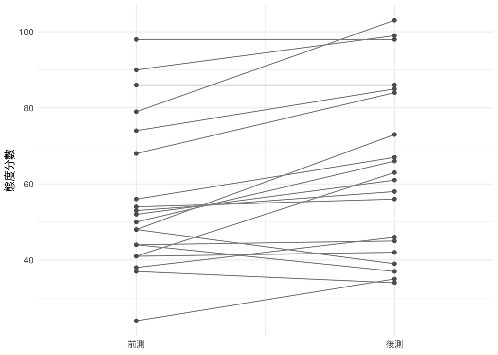

```r
# 前後測連線圖：每條灰線是一位學生，左端為前測、右端為後測
# x = 1 代表前測、x = 2 代表後測，再用 scale_x_continuous() 換成中文刻度標籤
film |>
  ggplot() +
  geom_segment(aes(x = 1, xend = 2, y = pre, yend = post),
               colour = "grey50") +              # 同一人前後測連線
  geom_point(aes(x = 1, y = pre), colour = "grey30") +   # 前測分數
  geom_point(aes(x = 2, y = post), colour = "grey30") +  # 後測分數
  scale_x_continuous(breaks = c(1, 2), labels = c("前測", "後測"),
                     limits = c(0.7, 2.3)) +
  labs(x = NULL, y = "態度分數") +
  theme_minimal()
```

```r
# 練習：
# 1. 用 paired = TRUE 做配對 t
# 2. 對 film$D 做單一樣本 t（mu = 0），確認 t 相同
# 3. 拿掉 paired = TRUE 再跑一次，比較 df、p 與信賴區間
# 4. 計算 d_z（分母為差值的標準差）
```

為什麼本例應該用配對 t？忘記 `paired = TRUE` 時，標準誤為什麼變大？

## 結論

用三到四句寫出問題 C 的結論：差的方向與大小（含單位）、95% 信賴區間、$t$、$df$、$p$、$d_z$，以及這個單組前後測設計能推論到哪裡。

來源：Week 09 t 檢定投影片三個案例；`week09_part2_film_attitude.csv` 由 t 檢定投影片的完整資料表轉錄（案例資料標示為 Devoe, 1990）。A、B 的示範資料由 `make_demo()` 產生，只用來練習 `t.test()` 的寫法。